# Microbial Mapping - R Notebook

# Summary of Microbial Mapping

This document is a guide to the different metadata categories, sample numbers, sampling sites, etc. that are included in the microbial mapping dataset.

The goal is to give a good introudction to the data collection and project structure. The final figure is a summary of all the samples that are included in the sequencing data.

## Libraries etc.

Load some basic data manipulation and visualization libraries. Set a standardized custom color scale for visualizations.

```r
library(dplyr)
library(ggplot2)
theme_set(theme_bw())
pal_d = "Spectral"
scale_colour_discrete <-  function(palname=pal_d, ...){
  scale_colour_brewer(palette=palname, ...)
}
scale_fill_discrete <-  function(palname=pal_d, ...){
    scale_fill_brewer(palette=palname, ...)
}
pal_c = "C"
uniform_gradient_color <- function(palname = pal_c){
  scale_color_viridis_c(option = palname)
}
# Can change these settings with viridis package
# With colour brewer, need add a line to each plot for continuous colors
# "scale_color_gradient2(low = "green", mid = "blue", high = "red")"
#  scale_colour_continuous <-  function(palname=pal_c, ...){
#    scale_colour_brewer(palette=palname, ...)
#  }
# #
#  scale_fill_continuous <-  function(palname=pal_c, ...){
#    scale_fill_brewer(palette=palname, ...)
#  }
```

## Reading in the metadata

The metadata has been split into unique sample metadata and preparation information. This is in accordance with the EMP data uploading guidelines. The ‘sample_name’ column links sample prep and collection metadata.

```r
# sample metadata
raw_samples  <- read.table("../data/raw/unique_waimea_hiseq_samples_emp.tsv", sep = "\t", header = T)
# library prep metadata
prep_16S <- read.table("../data/raw/combined_hiseqs_bioblitz_mapping - 16S_prep_info.tsv", sep = "\t", header = T)
prep_ITS <- read.table("../data/raw/combined_hiseqs_bioblitz_mapping - ITS_prep_info.tsv", sep = "\t", header = T)
head(raw_samples)
```

|  | sample_name | sample_id | collection_label | project_name | site_code | site_name | accessioned | sample_type | habitat | host | trophic | site_type | metadata | latitude_deg | longitude_deg | empo_1 | empo_2 | empo_3 | env_material | env_feature | env_biome | enve_biom_0 | envo_biom_1e | envo_biome_2 | envo_biome_3 | PI | Processing | common_name | family | … |
| --- | --- | --- | --- | --- | --- | --- | --- | --- | --- | --- | --- | --- | --- | --- | --- | --- | --- | --- | --- | --- | --- | --- | --- | --- | --- | --- | --- | --- | --- | --- |
| 1 | 933 | WMEA_00933_No_M2 | RockSwab1A-M2 | Keck | M2 | OutsideRocks | Yes | MarineRockSwab | Marine | Nonhost | Environmental | Core Waimea | submerged boulders | 21.63852 | -158.0706 | Free-living | Saline | Surface (saline) | biofilm material | biofilm | marine benthic biome | biome | aquatic biome | marine biome | marine benthic biome | Craig | NA | MarineRockSwab | NA | … |
| 2 | 934 | WMEA_00934_No_M2 | RockSwab1B-M2 | Keck | M2 | OutsideRocks | Yes | MarineRockSwab | Marine | Nonhost | Environmental | Core Waimea | submerged boulders | 21.63852 | -158.0706 | Free-living | Saline | Surface (saline) | biofilm material | biofilm | marine benthic biome | biome | aquatic biome | marine biome | marine benthic biome | Craig | NA | MarineRockSwab | NA | … |
| 3 | 935 | WMEA_00935_No_M2 | RockSwab1C-M2 | Keck | M2 | OutsideRocks | Yes | MarineRockSwab | Marine | Nonhost | Environmental | Core Waimea | submerged boulders | 21.63852 | -158.0706 | Free-living | Saline | Surface (saline) | biofilm material | biofilm | marine benthic biome | biome | aquatic biome | marine biome | marine benthic biome | Craig | NA | MarineRockSwab | NA | … |
| 4 | 936 | WMEA_00936_No_M2 | RockSwab2A-M2 | Keck | M2 | OutsideRocks | Yes | MarineRockSwab | Marine | Nonhost | Environmental | Core Waimea | submerged boulders | 21.63852 | -158.0706 | Free-living | Saline | Surface (saline) | biofilm material | biofilm | marine benthic biome | biome | aquatic biome | marine biome | marine benthic biome | Craig | NA | MarineRockSwab | NA | … |
| 5 | 937 | WMEA_00937_No_M2 | RockSwab2B-M2 | Keck | M2 | OutsideRocks | Yes | MarineRockSwab | Marine | Nonhost | Environmental | Core Waimea | submerged boulders | 21.63852 | -158.0706 | Free-living | Saline | Surface (saline) | biofilm material | biofilm | marine benthic biome | biome | aquatic biome | marine biome | marine benthic biome | Craig | NA | MarineRockSwab | NA | … |
| 6 | 938 | WMEA_00938_No_M2 | RockSwab2C-M2 | Keck | M2 | OutsideRocks | Yes | MarineRockSwab | Marine | Nonhost | Environmental | Core Waimea | submerged boulders | 21.63852 | -158.0706 | Free-living | Saline | Surface (saline) | biofilm material | biofilm | marine benthic biome | biome | aquatic biome | marine biome | marine benthic biome | Craig | NA | MarineRockSwab | NA | … |

```r
head(prep_16S)
```

|  | sample_name | barcode | linker | primer | extraction_kit | run_prefix | locus | target_gene | target_subfragment | sequencing_id | primer_plate | primer_well | forward_primer | reverse_primer | primer_name | pcr_plate | platform | instrument_model |
| --- | --- | --- | --- | --- | --- | --- | --- | --- | --- | --- | --- | --- | --- | --- | --- | --- | --- | --- |
| 1 | 933 | CCTCGCATGACC | GT | GTGYCAGCMGCCGCGGTAA |  | HiSeq-01-16S | bacterial16S | 16S rRNA | V4 | 101591 | 3 | A01 | 515f | 806r | 515rcbc192 | 20190801_16S_KAPA3G_EP03_EMPPP03_HiSeq01 | Illumina | Illumina HiSeq 2500 |
| 2 | 934 | CGCGCAAGTATT | GT | GTGYCAGCMGCCGCGGTAA |  | HiSeq-01-16S | bacterial16S | 16S rRNA | V4 | 101592 | 3 | B01 | 515f | 806r | 515rcbc204 | 20190801_16S_KAPA3G_EP03_EMPPP03_HiSeq01 | Illumina | Illumina HiSeq 2500 |
| 3 | 935 | AAGGCGCTCCTT | GT | GTGYCAGCMGCCGCGGTAA |  | HiSeq-01-16S | bacterial16S | 16S rRNA | V4 | 101593 | 3 | C01 | 515f | 806r | 515rcbc216 | 20190801_16S_KAPA3G_EP03_EMPPP03_HiSeq01 | Illumina | Illumina HiSeq 2500 |
| 4 | 936 | CGCAATGAGGGA | GT | GTGYCAGCMGCCGCGGTAA |  | HiSeq-01-16S | bacterial16S | 16S rRNA | V4 | 101594 | 3 | D01 | 515f | 806r | 515rcbc228 | 20190801_16S_KAPA3G_EP03_EMPPP03_HiSeq01 | Illumina | Illumina HiSeq 2500 |
| 5 | 937 | ACGGCGTTATGT | GT | GTGYCAGCMGCCGCGGTAA |  | HiSeq-01-16S | bacterial16S | 16S rRNA | V4 | 101595 | 3 | E01 | 515f | 806r | 515rcbc240 | 20190801_16S_KAPA3G_EP03_EMPPP03_HiSeq01 | Illumina | Illumina HiSeq 2500 |
| 6 | 938 | CATTTGACGACG | GT | GTGYCAGCMGCCGCGGTAA |  | HiSeq-01-16S | bacterial16S | 16S rRNA | V4 | 101596 | 3 | F01 | 515f | 806r | 515rcbc252 | 20190801_16S_KAPA3G_EP03_EMPPP03_HiSeq01 | Illumina | Illumina HiSeq 2500 |

```r
n_distinct(raw_samples$sample_name)
```

```
[1] 1784
```

```r
n_distinct(prep_16S$sample_name)
```

```
[1] 1751
```

## Preparation info

- *sample_name* = Unique integer coresponding to a sample taken from the field. Exception: controls duplicated across sequencing runs were given unique IDs for the same sample. Matches sample metadata column.
- *barcode* = 12-mer index from EMP aliquots. Unique per sample per run.
- *linker* = Primer linker sequences.
- *primer* = Primer sequence of barcoded primer.
- *extraction_kit* = DNA extraction kit used.
- *run_prefix* = Filename prefix for raw sequencing data.
- *locus* = Locus for amplification.
- *target_gene* = Target gene name.
- *target_subfragment* = Subfragment of gene targeted.
- *sequencing_id* = Unique integer ID for each sequenced well.
- *primer_plate* = Integer indicating primer plate that was used for amplification.
- *primer_well* = Well id of primer plate.
- *forward_primer* = Forward primer sequence.
- *reverse_primer* = Reverse primer sequence.
- *primer_name* = Primer name assigned to well.
- *pcr_plate* = Name of PCR plate from which sequence product originated.
- *platform* = Sequencing platform.
- *instrument_model* = Sequencing instrument model.

## Metadata Categories

Sample Identifiers:

- *sample_name* = Unique integer coresponding to a sample taken from the field. Exception: controls duplicated across sequencing runs were given unique IDs for the same sample.Matches preparation metadata column.
- *sample_id* = Unique integer combined with some abbreviated metadata information to make it more human readable. Useful for labelling tubes but not necessary for analysis.
- *collection_label* = Label as it was written on the original sampling tube. Once sample entered the lab, it was accessioned into the spreadsheet and assigned a unique sample_name.
- *project_name* = For microbial mapping, the project should be “Keck”. A few samples from other projects were included in this dataset.
- *geo_loc_name* = Sampling location following earth microbiome project.

Site Identifiers:

Sample Type:

- *sample_type* = Categorical variable unique to this project. Sampling at each site targeted these ‘sample types’, which were sampled as consistently as possible across sites.
- *habitat* = Categorical variable unique to this project indicating one of three habitat types.
- *host* = Categorical variable unique to this project indicating whether sample was host associated and broad host types.

Individual Sample: - *trophic* = Categorical variable unique to this project indicating trophic status of each sample. Determined individually for each sample and sometimes varies within a sample type. - *metadata* = Any other metadata for this sample. Equivalent to the “Description” column for qiime. - *common_name* = Common name for collected sample used for human readable summaries. - *family* = Family level taxonomy for host associated samples, when available. - *genus* = Genus level taxonomy for host associated samples, when available. - *species* = Species level taxonomy for host associated samples, when available. - *taxonomy_info* = State of taxnomic id. - *collection_timestamp* = Date of sample collection

EMP metadata - *empo_1* = Categorical variable following earth microbiome project. - *empo_2* = Categorical variable following earth microbiome project. - *empo_3* = Categorical variable following earth microbiome project. - *env_material* = Categorical variable following earth microbiome project. - *env_feature* = Categorical variable following earth microbiome project. - *env_biome* = Categorical variable following earth microbiome project. - *enve_biom_0* = Categorical variable following earth microbiome project. - *envo_biom_1e* = Categorical variable following earth microbiome project. - *envo_biome_2* = Categorical variable following earth microbiome project. - *envo_biome_3* = Categorical variable following earth microbiome project.

Sample Processing - *accessioned* = Sample management variable used to check whether the sample was accessioned once the entry had been created. - *PI* = Designated project PI responsible for sampling protocol. - *Processing* = Sample management variable used to keep track of additional sample processing prior to extraction.

## Data Clean Up

Some samples in this data set are not associated with the Waimea project. Filter those samples out.

```r
# projects
unique(raw_samples$project_name)
```

```
[1] Keck    <NA>    JoshMS  Amend   Alegado
Levels: Alegado Amend JoshMS Keck
```

```r
# filter by project
samples <- raw_samples %>% filter(project_name %in% c("Keck","JoshMS"))
```

## Broad Summary

Certain sample types were collected for each site in a given habitat. Summarize the sample types in each habitat and by each site to make sure verythign looks clean.

```r
# sample counts of each type by habitat
samples %>% select(habitat, sample_type) %>% group_by(habitat, sample_type) %>% summarise(n())
```

```
Factor `habitat` contains implicit NA, consider using `forcats::fct_explicit_na`Factor `habitat` contains implicit NA, consider using `forcats::fct_explicit_na`
```

| habitat | sample_type | n() |
| --- | --- | --- |
| Lab | DrosophilaLab | 36 |
| Marine | CCA | 57 |
| Marine | Coral | 63 |
| Marine | Limu | 124 |
| Marine | MarineInvert | 107 |
| Marine | MarineRockSwab | 72 |
| Marine | MarineSediment | 17 |
| Marine | WaterSaline | 30 |
| Riverine | AquaticGastropod | 10 |
| Riverine | DNetCoarsePOM | 21 |

[output cut: 44 more lines]

```r
# sample counts by site
samples %>% select(site_name, sample_type) %>% group_by(site_name) %>% summarise(n())
```

| site_name | n() |
| --- | --- |
| Beach | 147 |
| Confluence | 185 |
| DrumRoad | 149 |
| Entrance | 201 |
| Estuary | 179 |
| Lab | 162 |
| OutsideOcean | 58 |
| OutsideRocks | 67 |
| Ridge | 98 |
| SharksCove | 69 |

[output cut: 5 more lines]

## Trophic Summary

One of the main goals of this project is to track microbial communit characteristics across trophic levels.

```r
# summarise sample counts by trophicl level and habitat
troph_by_habitat <- samples %>% select(habitat, trophic) %>% group_by(habitat, trophic) %>% summarise(count = n())
```

```
Factor `habitat` contains implicit NA, consider using `forcats::fct_explicit_na`Factor `trophic` contains implicit NA, consider using `forcats::fct_explicit_na`
```

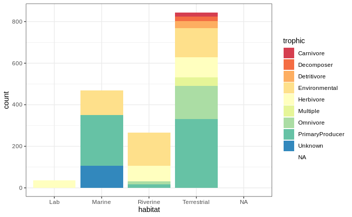

```r
# barplot of counts by habitat, stacked trophic levels
ggplot(troph_by_habitat, aes(y = count, x = habitat, fill = trophic )) +
  geom_bar(position="stack", stat="identity")
```

## Barplots

```r
## normal barplots
troph_data <- samples %>% group_by(habitat, common_name, trophic) %>% summarise(value = n())
```

```
Factor `habitat` contains implicit NA, consider using `forcats::fct_explicit_na`Factor `trophic` contains implicit NA, consider using `forcats::fct_explicit_na`
```

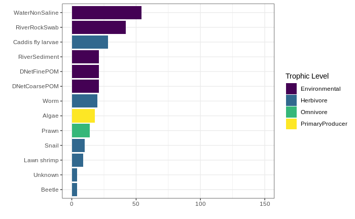

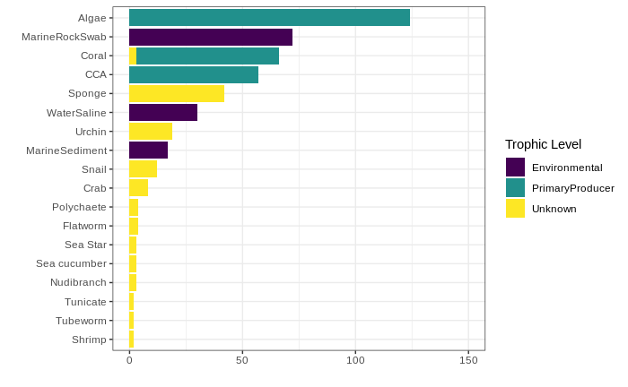

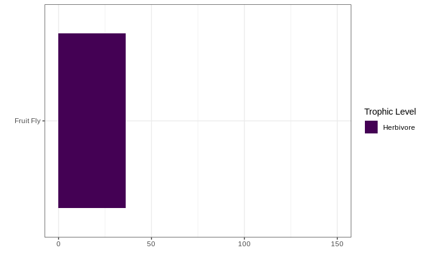

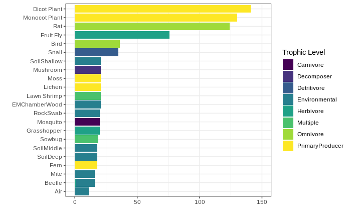

```r
troph_data$group <- troph_data$habitat
troph_data$key <- paste(troph_data$habitat, troph_data$common_name)
troph_data <- troph_data[!is.na(troph_data$habitat),]
## unique ids for each bar
ids <- troph_data %>% group_by(key, habitat) %>% summarise(tot = sum(value))
ids <- arrange(ids,habitat,tot)
ids$id <- 1:nrow(ids)
troph_data <- left_join(troph_data, ids)
troph_data <- arrange(troph_data, habitat, tot)
habitats <- unique(troph_data$habitat)
habitats <- unique(troph_data$habitat)
for (a in seq_along(habitats)) {

  habidata <- troph_data[troph_data$habitat == habitats[a],]

p<- ggplot(data=habidata, aes(x=reorder(common_name,id), y = value, fill=trophic)) +
  geom_bar(stat = "identity") +
  labs(fill ="Trophic Level")+
  scale_fill_viridis_d(option = "viridis")+
  coord_flip()+
  labs(y = "", x = "")+
  ylim(0,150)
print(p)
ggsave(file = paste("../outputs/figures/_", habitats[a],"_barplot.pdf",sep = ""),
       plot = p, device = "pdf", width = 10, height = 10, dpi = 400)
}
```

## Circle Barplot

See RGraph Gallery for more detailed explanation on how this works.

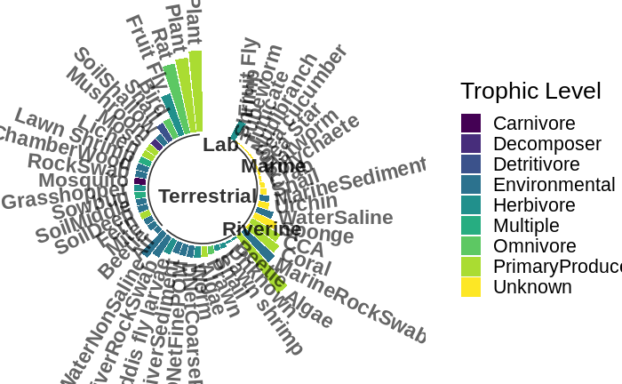

```r
# calculate the ANGLE of the labels
label_data <- troph_data %>% group_by(id, common_name) %>% summarize(tot=sum(value))
number_of_bar <- nrow(label_data)
angle <- 90 - 360 * (label_data$id-0.5) /number_of_bar     # I substract 0.5 because the letter must have the angle of the center of the bars. Not extreme right(1) or extreme left (0)
label_data$hjust <- ifelse( angle < -90, 1, 0)
label_data$angle <- ifelse(angle < -90, angle+180, angle)
# prepare a data frame for base lines
base_data <- troph_data %>%
  group_by(group) %>%
  summarize(start=min(id), end=max(id)) %>%
  rowwise() %>%
  mutate(title=mean(c(start, end)))
# prepare a data frame for grid (scales)
grid_data <- base_data
grid_data$end <- grid_data$end[ c( nrow(grid_data), 1:nrow(grid_data)-1)] + 1
grid_data$start <- grid_data$start - 1
grid_data <- grid_data[-1,]
# Limits of the plot = very important. The negative value controls the size of the inner circle, the positive one is useful to add size over each bar
p<- ggplot(data=troph_data, aes(x=factor(id), y = value, fill=trophic)) +
  geom_bar(stat = "identity") +
  labs(fill ="Trophic Level")+
  scale_fill_viridis_d(option = "viridis")+

  ylim(-100,210) +

  # Custom the theme: no axis title and no cartesian grid
  theme_minimal(base_size = 20) +
  theme(
      axis.text = element_blank(),
      axis.title = element_blank(),
      panel.grid = element_blank(),
      plot.margin = unit(rep(-1,4), "cm")# Adjust the margin to make in sort labels are not truncated!
    ) +
#   #
#   # # This makes the coordinate polar instead of cartesian.
   coord_polar(start = 0)  +
  # add base line information
  geom_segment(data=base_data, aes(x = start, y = -5, xend = end, yend = -5), colour = "black", alpha=0.8, size=0.6 , inherit.aes = FALSE )  +
  geom_text(data=base_data, aes(x = title - 5, y = -22, label=group), hjust=c(0,0,0,0), colour = "black", alpha=0.8, size=6, fontface="bold", inherit.aes = FALSE)+
#   # # Add the labels, using the label_data dataframe that we have created before
geom_text(data=label_data, aes(x=factor(id), y=tot+10, label=common_name, hjust=hjust), color="black", fontface="bold",alpha=0.6, size=6, angle= label_data$angle, inherit.aes = FALSE )
#
p
#
ggsave("../outputs/figures/habitat_sample_type_circleplot.pdf",plot = p, device = "pdf", width = 15, height = 10, dpi = 400)
```

## Sunburst

```r
orca(fig, file = "../outputs/figures/summary_sunburst.pdf",format ="pdf")
```

[output not shown]

[output not shown]

[output not shown]